### ステップ２

[figure not shown]

### ステップ３

[figure not shown]

### ステップ４

[figure not shown]

### ステップ５

[figure not shown]

# 問題３：$\chi^2$ 検定，オッズ比，ロジスティック回帰モデル

1990年代，アフリカのナイジェリア北部でオンコセルカ症 (回旋糸状虫症, onchocerciasis; river blindness とも呼ばれる) が流行していた．ある研究チームは流行地域にある34個の村に住む15歳以上の全住民に目の検査を行った．目の検査受けた住民はWHOの診断基準をもとに，「視覚障害 (visually impaired)」と「視力正常 (normal vision」に分類された．対象者は 3 年間観察され，その期間中に死亡者が登録された．

## 視覚障害と死亡の関係

### 答え

$$\begin{aligned}
\chi^2 & = \frac{(3874 - 3844.4232)^2}{3844.4232} + \frac{(287 - 316.5768)^2}{316.5768} + \frac{(97 - 126.5768)^2}{126.5768} + \frac{(40 - 10.4232)^2}{10.4232} \\
& = 93.829
\end{aligned}$$

### 2 $\times$ 2 の分割表では，自由度は $(2-1)\times(2-1) = 1$ ．

EZRで，$\chi^2$統計量と自由度(df)を使って P 値を計算したい場合は，以下のコマンドを利用してください：

```r
2*pchisq(chisquare統計量, df, lower = FALSE)
```

```r
2*pchisq(93.829, 1, lower = FALSE)
```

```
## [1] 6.879894e-22
```

[figure not shown]

以下のコードをRスクリプトに入力して,実行をクリックしてください.自分で計算した検定結果と一致するかを確認してください．

```r
source("http://aoki2.si.gunma-u.ac.jp/R/src/my-chisq-test.R", encoding="euc-jp")
a <- my.chisq.test(matrix(c(3874, 97, 287, 40), nrow = 2))
a$expected # 期待者数表
```

```
##           [,1]      [,2]
## [1,] 3844.4232 316.57678
## [2,]  126.5768  10.42322
```

```r
a
```

```
##
##  カイ二乗分布を用いる独立性の検定（残差分析）
##
## data:  matrix(c(3874, 97, 287, 40), nrow = 2)
## X-squared = 93.829, df = 1, p-value < 2.2e-16
```

[figure not shown]

この検定結果は「視覚障害と対象者の死亡リスクに関連がない」という帰無仮説を棄却するために非常に強い証拠を提供したと言える．

There is strong evidence against the null hypothesis that there is no association between visual impairment and risk of death.

視覚障害と死亡の関連を示すオッズ比は：

$$\mathbf{OR} = 0.1394 \div 0.025 = 5.576$$

このオッズ比の対数を取った値 $\mathbf{log(OR)}$ は：

$$\mathbf{log(OR)} = 1.717$$

### EZRでロジスティック回帰モデルを作る

#### ステップ１ — データのインポート

[figure not shown]

[figure not shown]

[figure not shown]

[figure not shown]

[figure not shown]

#### ステップ２ — ロジスティックモデルを作る

[figure not shown]

[figure not shown]

[figure not shown]

[figure not shown]

計算したオッズ比がこの結果と一致しているかを確認してください．

10. 出力のところをスクロールアップすると $\mathbf{log(OR)}$ の結果が確認できる

[figure not shown]

- (intercept/切片) の `-3.689` は”視力正常”群の対数オッズであることが確認できる；
- `vimp` (視覚障害)の回帰係数 `1.7167` は”視覚障害”群と”視力正常”群を比べた log(OR) = log(odds in 視覚障害) - log(odds in 視力正常) = -1.9704 - (-3.689)である．

## 年齢の影響を考慮する

各年齢層では，視覚障害と死亡の関係を評価するオッズ比は大きく異なることがわかり，年齢と共に減っていく傾向があるかもしれない．年齢を考慮せずに視覚障害と死亡との関係を評価することは妥当ではないことが示唆される．

Look at the stratum-specific odds ratios, it appears that there may be a trend and that the odds ratio for visual impairment may decline with age.

### EZRで年齢グループを調整したロジスティック回帰モデルを作る

#### 年齢グループ `agegrp` 変数を因子 (factor) に変換する

[figure not shown]

[figure not shown]

[figure not shown]

4. 水準名に各年齢グループの名前を入力する

[figure not shown]

#### 多変量ロジスティック回帰モデルを作る

[figure not shown]

2. `agegrp` が因子になったことが確認できる．`died` (死亡) を目的変数へ，`vimp` (視覚障害) を説明変数へ

[figure not shown]

3. `agegrp` も説明変数変数へ移動すると自動的に `+` が付加される．OKをクリックする．

[figure not shown]

4. 視覚障害と死亡の関係を評価する年齢調整オッズ比が計算される．

[figure not shown]

#### 単変量ロジスティック回帰モデルで評価した粗オッズ比 (crude odds ratio) と比べ，年齢調整オッズ比はどう変わったかを説明せよ．

#### 答え

- 年齢を考慮していない場合，視覚障害者は視力正常者と比べ，3年の間に死亡するオッズが5.57倍であり，95%信頼区間が 3.78 - 8.20 と推定される．
- 多変量ロジスティクス回帰モデルを用いて，視覚障害と死亡の関係に年齢の交絡考慮した後，オッズ比が 2.20 になり，95%信頼区間が 1.41 - 3.44 と推定される．
- このオッズ比が大きく変化した（小さくなった）ことは，年齢がこの関連の強い交絡因子であることを示唆している．
- また，年齢調整したオッズ比の95%信頼区間は 1 を跨いでいない．

以上の結果を踏まえて，「視覚障害者が視力正常者と比べ，観察期間中に死亡するオッズ比は1と等しい」を棄却するために，非常に強い証拠を提供した．

(なお，この解析は，「各年齢層内の視覚障害と死亡の関係が等しい」という前提が仮定される．つまり，2.20は各年齢層の視覚障害と死亡の関係を評価する共通オッズ比 [common odds ratio] である．)

# 問題４：生存分析

問題３の研究では対象者が研究に参加した時点，研究終了時点（死亡，打ち切り，及び研究期間が終了した）の日付も記録されている：

```
## # A tibble: 4,298 x 6
##       id agegrp enter      exit                        vimp  died
##    <dbl> <fct>  <date>     <date>                 <dbl+lbl> <dbl>
##  1     1 55-64  1989-05-09 1992-02-05 0 [Normal]                0
##  2     2 35-54  1989-05-09 1992-02-05 0 [Normal]                0
##  3     3 35-54  1989-05-09 1992-02-05 1 [Visually impaired]     0
##  4     4 15-34  1989-05-09 1992-02-05 0 [Normal]                0
##  5     5 15-34  1989-05-09 1992-02-05 0 [Normal]                0
##  6     6 15-34  1989-05-09 1989-08-12 0 [Normal]                0
##  7    14 65+    1989-05-09 1992-02-05 0 [Normal]                0
##  8    15 55-64  1989-05-11 1992-02-05 1 [Visually impaired]     0
##  9    16 35-54  1989-05-12 1992-02-05 1 [Visually impaired]     0
## 10    17 35-54  1989-05-09 1992-02-05 0 [Normal]                0
## 11    18 15-34  1989-05-09 1992-02-05 0 [Normal]                0
## 12    19 15-34  1989-05-12 1992-02-05 0 [Normal]                0
```

[output cut: 24 more lines]

### EZRでは，追跡期間を計算するために，日付の差を取る必要がある

[figure not shown]

2. 追跡期間の変数名を `followup` とする

[figure not shown]

3. `followup` を作成したと確認メッセージが出る．追跡期間の要約を調べる：

[figure not shown]

4. イベント別（死亡，打ち切り）により追跡期間を計算する

[figure not shown]

[figure not shown]

[figure not shown]

7. 単純要約を見ると，死亡者と生存者の追跡期間（日数）の平均値(と中央値)はどちらが長いか？

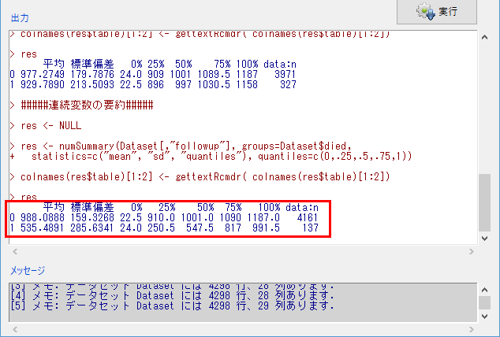

8. 層別変数を `vimp` (視覚障害) に変更し，追跡期間の要約を比較する

[figure not shown]

[figure not shown]

10. 視覚障害者と視力正常者で，追跡期間の違いはあるか？

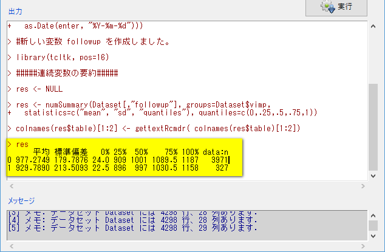

### 生存表とカプランマイヤーグラフを作成する

[figure not shown]

[figure not shown]

3. 視覚障害者（赤線）と視力正常者（黒線）のカプランマイヤー生存曲線： （点線は95%信頼区間を示す）

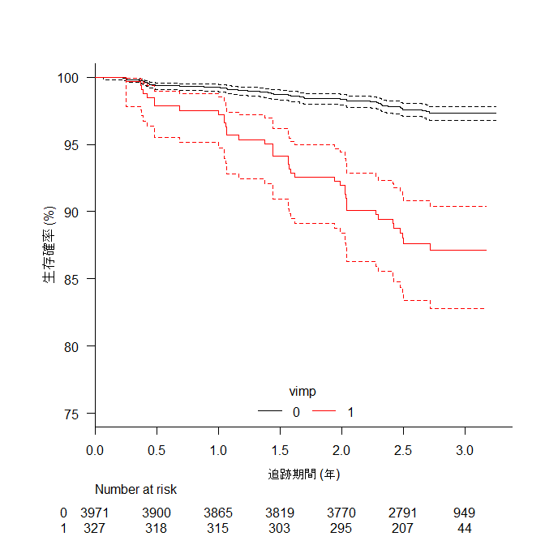

4. log-rank 検定の結果も同時に示される．$p = <2e-16 < 0.00001$の結果から，「視覚障害者と視力正常者の生存曲線が等しい」という帰無仮説を棄却するために非常に強い証拠を提供した．

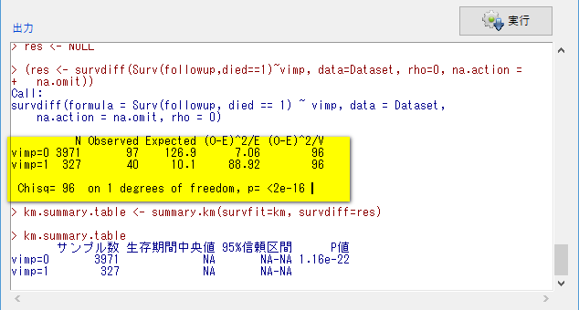

5. 生存曲線を作成するための両群の生存率表も確認できる：

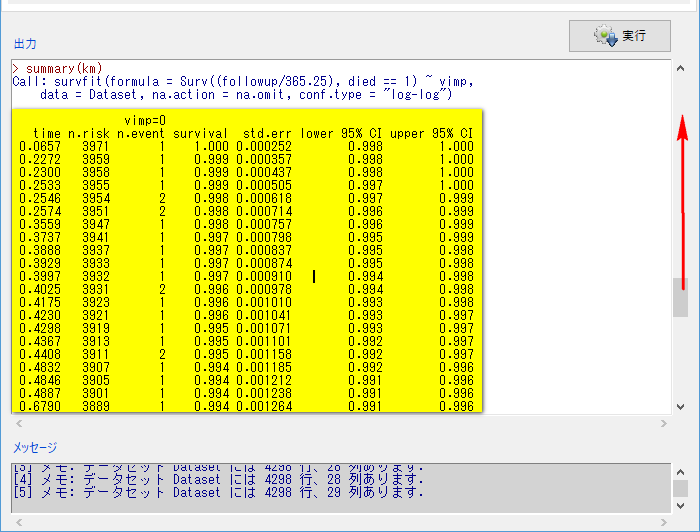

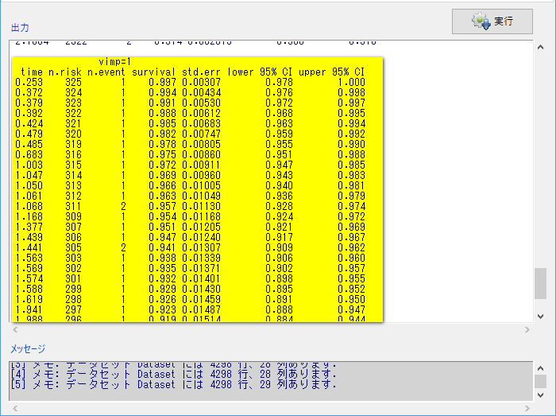

### Cox比例ハザードモデルを作る．

[figure not shown]

2. `followup`を時間へ

[figure not shown]

3. `died`をイベントへ

[figure not shown]

4. `vimp` (視覚障害)を説明変数へ，OKをクリックする

[figure not shown]

5. 単変量ハザード比，及び信頼区間の意味を説明せよ．

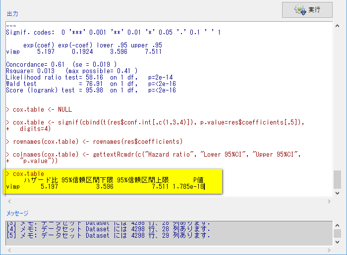

### 答え

以上の結果から，「視覚障害者が視力正常者と比べ，観察期間中に死亡するハザード比は1と等しい」を棄却するために，非常に強い証拠を提供した．

6. 年齢調整ハザード比を求めよ．

[figure not shown]

7.年齢調整ハザード比，及び信頼区間の意味を説明せよ．

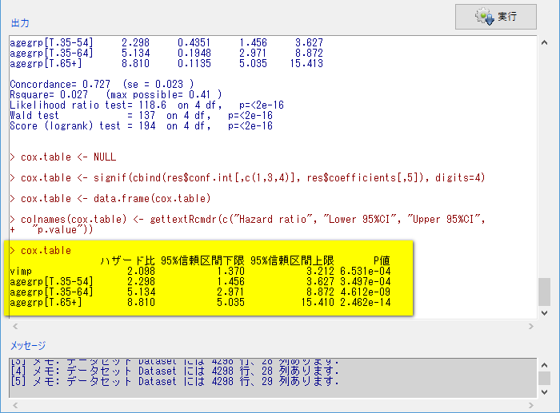

### 答え

- 三年間の追跡期間における，視覚障害者の年齢調整死亡ハザードは視力正常者の 2.10 倍，このハザード比の 95% 信頼区間は 1.37 - 3.21 と推定される．
- 年齢調整ハザード比の95%信頼区間は 1 を跨いでいない．

以上の結果から，「視覚障害者が視力正常者と比べ，観察期間中に死亡する年齢調整ハザード比は1と等しい」を棄却するために，非常に強い証拠を提供した．

# 参考図書：

1. 中澤 港，「Rによる保健医療データ解析演習」，（http://minato.sip21c.org/msb/medstatbookx.pdf）から入手できる
2. 新谷 歩，「みんなの医療統計 12日間で基礎理論とEZRを完全マスター!」．